# Coding 2: Final Term Project

Ali Sial

12/21/2021

## Aim of the assignment

The main goal of this project was to scrape all the data on aircraft and their manufacturers (including all specifications) from AeroCorner.com. There are a total of 110 manufacturers and 914 aircraft in total. The final data extracted contains 914 observations (aircraft names) and all it’s specification that was available on the website, this is stored as 34 different variables.

## Process Overviw

The data was store in three different links and 918 pages on the website, to extract the data, I created five functions. This data was stored in five different tables which were then combined to get on data table. Since running the functions used to retrieve data takes a lot of time when knitting the file, I decided to save the data in a CSV file and uploaded to my GitHub repository. I will be calling the data used for analysis in this exercise using this. The code for the entire scrapping process is add to the Rmd file as text and can also be retrieved from the same GitHub repository.

## Data Cleaning & Munging

The final scrapped dataset was very unorganised, thus required some cleaning before it could be used for analysis. All the table’s type was character and rather than munging all the data, I decided to filter the tables that were needed for my analysis and adjusted them to our requirements.

## Analysis

The second goal of this project was to produce some meaning full questions that this data can answer and provide us with some insides about the Avionics Industry. The three questions that I would be visualising with this data are:

- Count of different aircraft each manufacturer produces.
- To understand if there is a liner relation between Price of the Aircraft and it’s Horse Power
- To uncover pattern of association between the Fuel Economy of aircrafts and their Fuel Tank Capacity

## Number of Aircrafts by Manufacturers

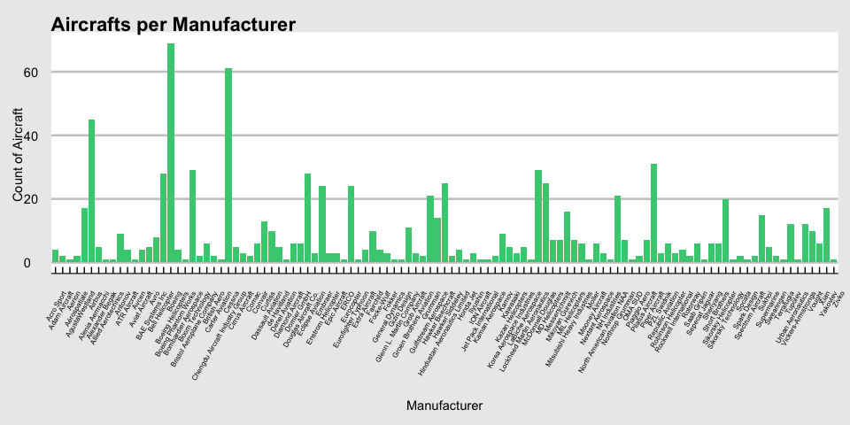

## Linear Relation Between Price Vs Horse Power

Here, I wanted to check if the price of aircraft is somehow correlated with it’s horse power. This means that when the horse power increase the price should either increase or decrease. The graph below depicts that the linear relation between these the two variables, and it appears to be positive which means with and increase in horse power the price also increases. To further validate this observation, I ran a regression for these variables and the $\beta$ coefficient suggests that price to increase by 1.67% if horse power is higher by 1%.

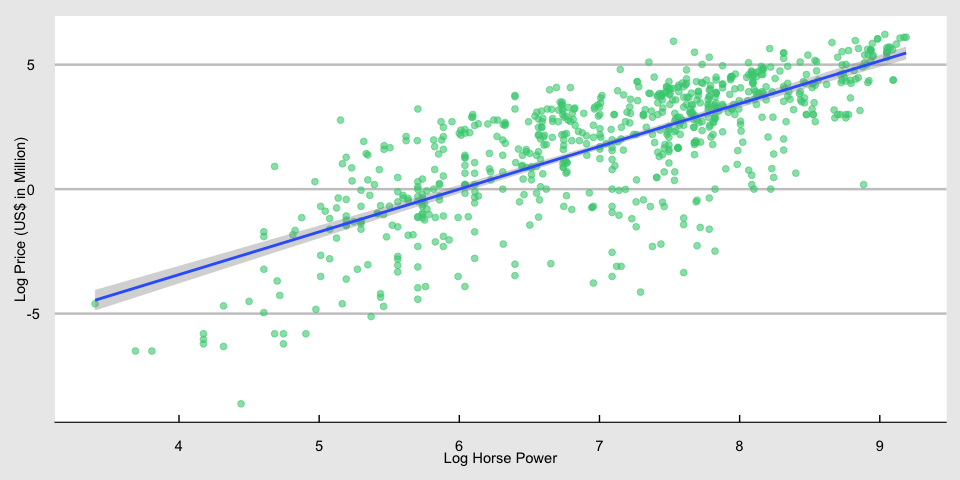

## Linear Relation between Fuel Economy Vs Fuel Tank Size

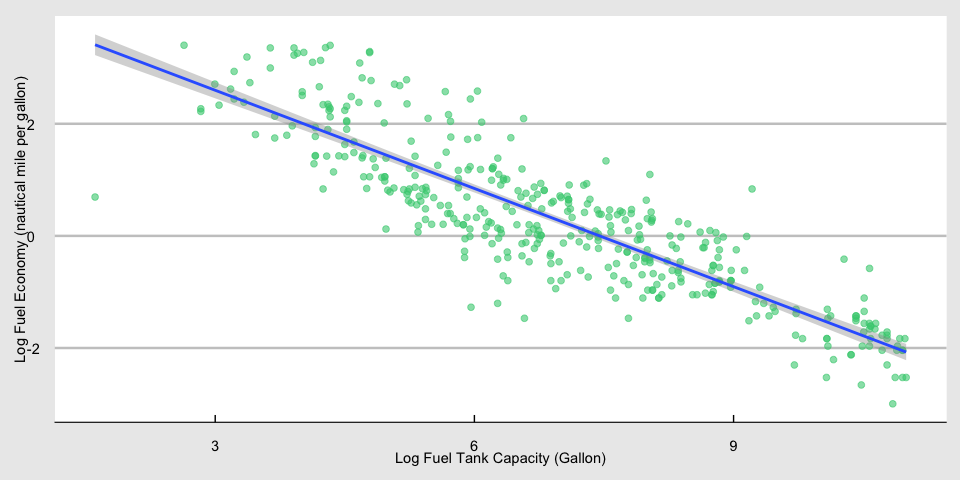

## Conclusion

Overall, this project was a great learning experience about how data can easily be obtained form different sources when we don’t have a read made data available for the analysis we intend to perform. The questions that I wanted to analyse in this project have also been answered well by the data. I understand the analysis performed is not very reliable be it provides the viewer with a starting point to further expand the horizon of this analysis.